# dataRetrieval Tutorial

10 March, 2016

## Introduction

What is `dataRetrieval`?

- R-package to get USGS/EPA water data into R

Where does the data come from?

- US Geological Survey water data
  - National Water Information System (NWIS)
- Water Quality Portal
  - USGS
  - EPA (EPA Storage and Retrieval Data Warehouse = STORET)
  - USDA
  - more being added….

What does `dataRetrieval` do to the data?

How to discover data?

- Examples will be provided

## Overview

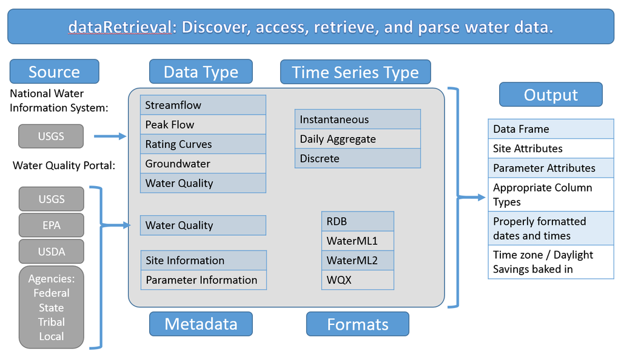

## Installation

`dataRetrieval` is available on the CRAN repository. The CRAN version is the most stable and user-tested:

```r
install.packages("dataRetrieval")
```

Bug fixes and feature upgrades are vetted through a version of `dataRetrieval` that is available on a USGS-maintained R repository. To install from that repository:

```r
install.packages("dataRetrieval",
                 repos=c("http://owi.usgs.gov/R",
                         getOption("repos")))
```

More information can be found [here](http://owi.usgs.gov/R/gran.html).

Finally, the absolute cutting-edge version of `dataRetrieval` can be installed using the `devtools` package which pulls from GitHub:

```r
library(devtools)
install_github("USGS-R/dataRetrieval")
```

## dataRetrieval Help

Once the `dataRetrieval` package has been installed, it needs to be loaded in order to use any of the functions:

```r
library(dataRetrieval)
```

There is a vignette that covers the full scope of the `dataRetrieval` package. It can be accessed with the following command:

```r
vignette("dataRetrieval",package = "dataRetrieval")
```

Additionally, each function has a help file. These can be accessed by typing a question mark, followed by the function name in the R console:

```r
?readNWISuv
```

Each function's help file has working examples to demonstrate the usage. The examples may have comments "## Not run". These examples CAN be run, they just are not run by the CRAN maintainors due to the external service calls.

Finally, if there are still questions that the vignette and help files don't answer, please post an issue on the `dataRetrieval` GitHub page:

https://github.com/USGS-R/dataRetrieval/issues

## US Geological Survey Water Data Overview

National Water Information System (NWIS)

- Unit Data
  - "Real-time" data
  - Available data from 2007 (big improvement from 120 days!)
- Daily Data
  - Data aggregated from the unit data to a daily statistic
  - This data can go back many decades
- Discrete Data
  - Water quality data
  - Groundwater level
  - Rating curves
  - Surfacewater measurements
- Meta Data
  - Site information
  - Parameter information

## USGS Basic Web Retrievals

The USGS uses various codes for basic retrievals

- Site ID (often 8 or 15-digits)
- Parameter Code (5 digits)
  - [More information](http://help.waterdata.usgs.gov/code/parameter_cd_query?fmt=rdb&inline=true&group_cd=%)
- Statistic Code (for daily values)
  - [More information](http://help.waterdata.usgs.gov/code/stat_cd_nm_query?stat_nm_cd=%25&fmt=html)

Here are some examples of common codes:

| Parameter Codes | Short Name |
| --- | --- |
| 00060 | Discharge |
| 00065 | Gage Height |
| 00010 | Temperature |
| 00400 | pH |

| Statistic Codes | Short Name |
| --- | --- |
| 00001 | Maximum |
| 00002 | Minimum |
| 00003 | Mean |
| 00008 | Median |

## USGS Basic Web Retrievals: readNWISuv

Knowing a site number (or site numbers), paremeter code (or codes), and start and end date. Let's start by asking for discharge (parameter code = 00060) data for the Yahara River at Windsor, WI (an inlet to Lake Mendota).

```r
siteNo <- "05427718"
pCode <- "00060"
start.date <- "2014-10-01"
end.date <- "2015-09-30"

yahara <- readNWISuv(siteNumbers = siteNo,
                     parameterCd = pCode,
                     startDate = start.date,
                     endDate = end.date)
```

## USGS Basic Web Retrievals: renameNWISColumns

From the Yahara example, let's look at the data. The column names are:

```r
names(yahara)
```

```
## [1] "agency_cd"        "site_no"          "dateTime"
## [4] "X_00060_00011"    "X_00060_00011_cd" "tz_cd"
```

The names of the columns are based on the parameter and statistic codes. In many cases, you can clean up the names with a convenience function renameNWISColumns:

```r
yahara <- renameNWISColumns(yahara)
names(yahara)
```

```
## [1] "agency_cd"    "site_no"      "dateTime"     "Flow_Inst"
## [5] "Flow_Inst_cd" "tz_cd"
```

## Explore Data

```r
head(yahara)
```

```
##   agency_cd  site_no            dateTime Flow_Inst Flow_Inst_cd tz_cd
## 1      USGS 05427718 2014-10-01 05:00:00        16            A   UTC
## 2      USGS 05427718 2014-10-01 05:15:00        16            A   UTC
## 3      USGS 05427718 2014-10-01 05:30:00        16            A   UTC
## 4      USGS 05427718 2014-10-01 05:45:00        16            A   UTC
## 5      USGS 05427718 2014-10-01 06:00:00        16            A   UTC
## 6      USGS 05427718 2014-10-01 06:15:00        16            A   UTC
```

| Column Name | Type |
| --- | --- |
| agency_cd | chr |
| site_no | chr |
| dateTime | POSIXct |
| Flow_Inst | num |
| Flow_Inst_cd | chr |
| tz_cd | chr |

## Explore Data (cont.)

The returned data also has several attributes attached to the data frame. To see what the attributes are:

```r
names(attributes(yahara))
```

```
## [1] "names"         "row.names"     "class"         "url"
## [5] "siteInfo"      "variableInfo"  "disclaimer"    "statisticInfo"
## [9] "queryTime"
```

Each `dataRetrieval` return should have the attributes url, siteInfo, and variableInfo. Additional attributes are available depending on the data.

To access the attributes:

```r
url <- attr(yahara, "url")
```

[Raw Data](http://nwis.waterservices.usgs.gov/nwis/iv/?site=05427718&format=waterml,1.1&ParameterCd=00060&startDT=2014-10-01&endDT=2015-09-30)

## Explore Data (cont.)

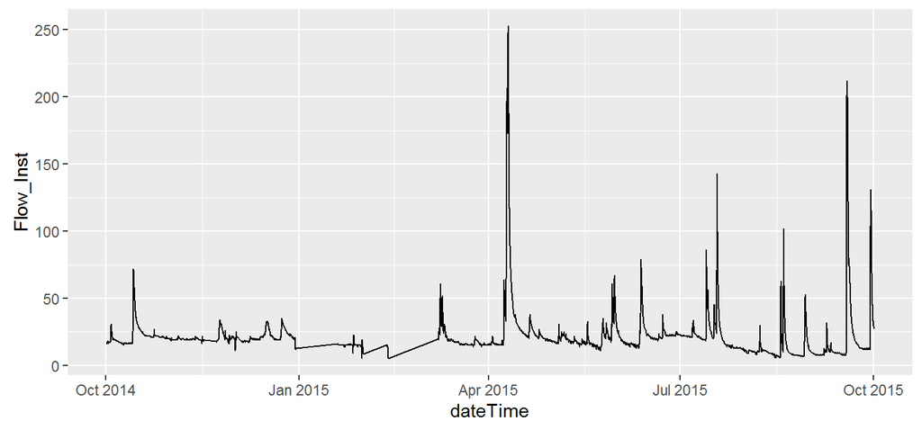

```r
library(ggplot2)
ts <- ggplot(yahara,
             aes(dateTime, Flow_Inst)) +
      geom_line()
ts
```

## Use attributes for metadata:

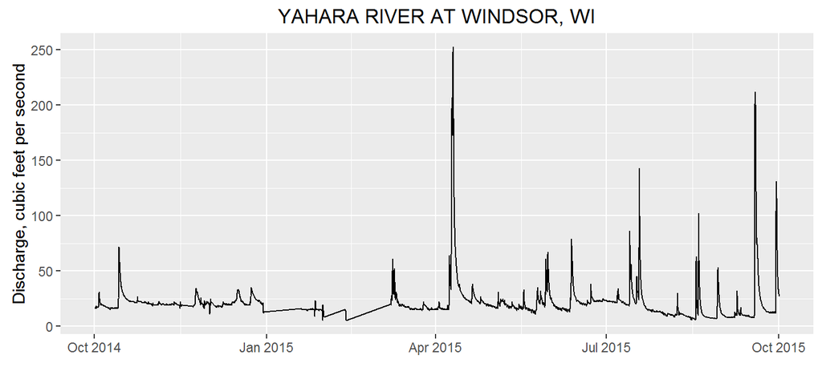

```r
parameterInfo <- attr(yahara, "variableInfo")
siteInfo <- attr(yahara, "siteInfo")

ts <- ts +
      xlab("") +
      ylab(parameterInfo$parameter_desc) +
      ggtitle(siteInfo$station_nm)
ts
```

## USGS Basic Web Retrievals: readNWISdv

The unit value discharge data is 15 minute data availabe back to 2007.

Daily mean data is available for that site back to 1976.

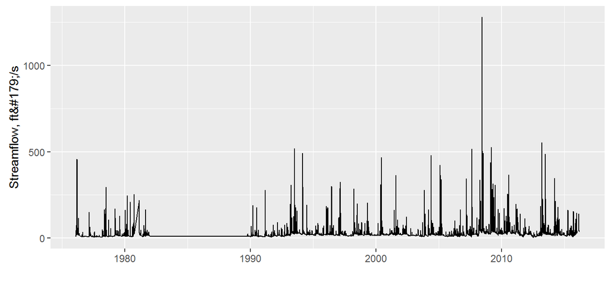

```r
daily <- readNWISdv(siteNo, pCode)
daily <- renameNWISColumns(daily)
dd <- ggplot(daily, aes(Date,Flow)) +
  xlab("") +
  ylab(attr(daily,"variableInfo")$parameter_nm) +
  geom_line()
dd
```

## Multiple site and parameters

The NWIS functions can be used to get multiple sites and multiple parameters in one call.

```r
sites <- c("05427850","05427718") # 2 stations on Yahara
pCodes <- c("00060","00010") #Temperature and discharge

multi <- readNWISuv(sites,pCodes, "2016-03-01","2016-03-08")
multi <- renameNWISColumns(multi)

names(multi)
```

```
## [1] "agency_cd"     "site_no"       "dateTime"      "Wtemp_Inst"
## [5] "Flow_Inst"     "Wtemp_Inst_cd" "Flow_Inst_cd"  "tz_cd"
```

```r
variableInfo <- attr(multi, "variableInfo")
siteInfo <- attr(multi, "siteInfo")
```

## Multiple site and parameters (cont.)

Base R plots:

```r
par(mfcol=c(2,1),oma=c(2,1,1,1), mar=c(1,4,0.1,0.1))

site1 <- multi[multi$site_no == sites[1],]
site2 <- multi[multi$site_no == sites[2],]
plot(site1$dateTime, site1$Flow_Inst, type="l",col="red",
     xlab = "",xaxt="n",
     ylab=variableInfo$param_units[variableInfo$parameterCd == "00060"])

lines(site2$dateTime, site2$Flow_Inst)
plot(site1$dateTime, site1$Wtemp_Inst, type="l",col="red",
     xlab = "",
     ylab=variableInfo$param_units[variableInfo$parameterCd == "00010"])
lines(site2$dateTime, site2$Wtemp_Inst)
legend("topleft", legend = siteInfo$site_no,
       cex=0.75, col = c("red","black"),lwd = 1)
box()
```

## Multiple site and parameters (cont.)

Base R plots:

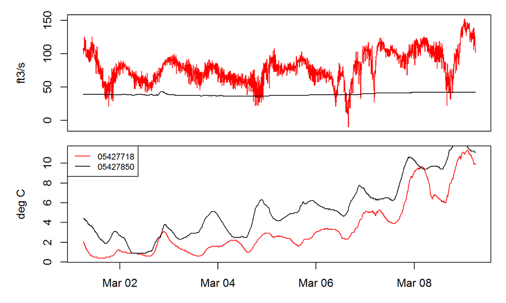

## Multiple site and parameters (cont.)

ggplot2: Reshape data from "wide" to "long" first using `tidyr` package.

```r
library(tidyr)
library(dplyr)
multi.data <- select(multi, site_no, dateTime, Wtemp_Inst, Flow_Inst)
head(multi.data)
```

```
##    site_no            dateTime Wtemp_Inst Flow_Inst
## 1 05427718 2016-03-01 06:00:00        4.4        39
## 2 05427718 2016-03-01 06:05:00        4.4        39
## 3 05427718 2016-03-01 06:10:00        4.4        39
## 4 05427718 2016-03-01 06:15:00        4.4        39
## 5 05427718 2016-03-01 06:20:00        4.4        39
## 6 05427718 2016-03-01 06:25:00        4.4        39
```

```r
longMulti <- gather(multi.data, variable, value, -site_no, -dateTime)
head(longMulti)
```

```
##    site_no            dateTime   variable value
## 1 05427718 2016-03-01 06:00:00 Wtemp_Inst   4.4
## 2 05427718 2016-03-01 06:05:00 Wtemp_Inst   4.4
## 3 05427718 2016-03-01 06:10:00 Wtemp_Inst   4.4
## 4 05427718 2016-03-01 06:15:00 Wtemp_Inst   4.4
## 5 05427718 2016-03-01 06:20:00 Wtemp_Inst   4.4
## 6 05427718 2016-03-01 06:25:00 Wtemp_Inst   4.4
```

## Multiple site and parameters (cont.)

ggplot2: Reshape data from "wide" to "long" first using `tidyr` package.

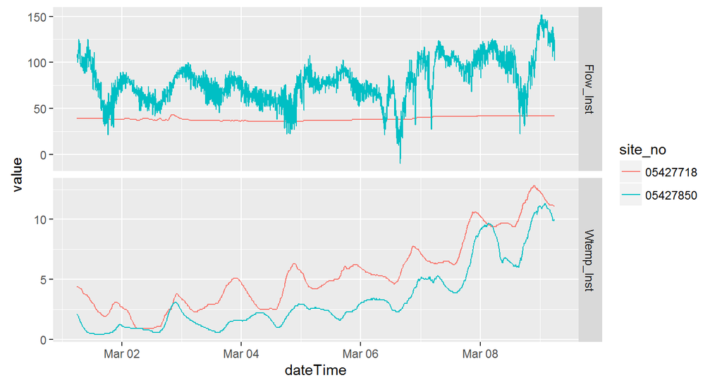

```r
gp <- ggplot(longMulti,
             aes(dateTime, value, color=site_no)) +
  geom_line() +
  facet_grid(variable ~ .,scales= "free")
gp
```

## Multiple site and parameters (cont.)

To demonstrate the power of `tidyr` + `dplyr` + `ggplot2` + `dataRetrieval`:

```r
sites <- c("05427850","05427718","05428000","05427880")
pCodes <- c("00060","00010","00055","00065")

wideMulti <- readNWISuv(sites,pCodes, "2016-03-01","2016-03-08") %>%
         select(-ends_with("_cd"))

siteInfo <- attr(wideMulti, "siteInfo")
paramInfo <- attr(wideMulti, "variableInfo")

longMulti <- gather(wideMulti, variable, value, -site_no, -dateTime) %>%
         mutate(variable = as.factor(variable)) %>%
         mutate(site_no = as.factor(site_no))

levels(longMulti$variable) <- paramInfo$param_units
levels(longMulti$site_no) <- siteInfo$station_nm

gp <- ggplot(longMulti,
             aes(dateTime, value, color=site_no)) +
  geom_line(size=1.5) + xlab("") + ylab("") +
  facet_grid(variable ~ .,scales= "free") +
  theme(legend.title=element_blank(),
        legend.position='bottom',legend.direction = "vertical")
gp
```

## Multiple site and parameters (cont.)

To demonstrate the power of `tidyr` + `dplyr` + `ggplot2` + `dataRetrieval`:

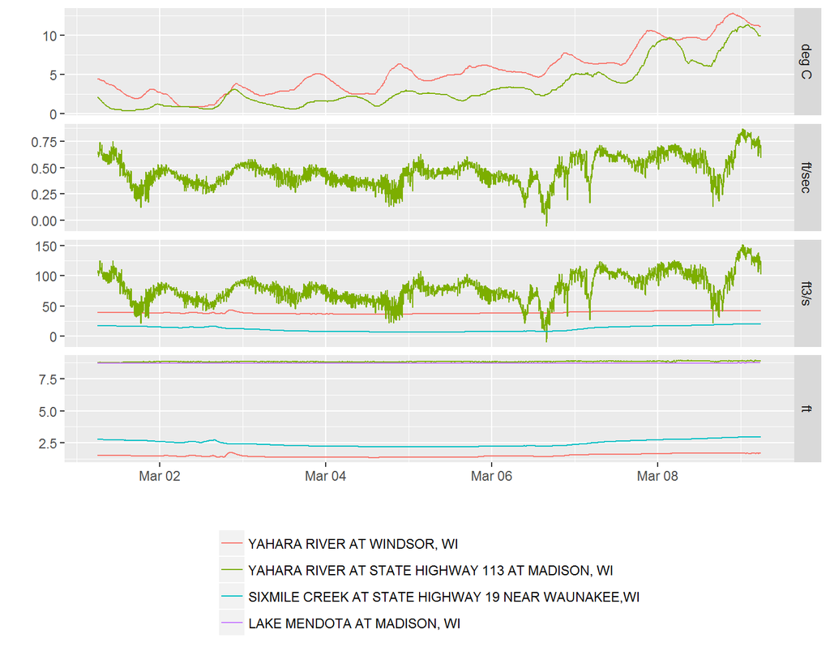

## USGS Advanced Retrievals: Discover Data

This is all great when you know your site numbers.

What do you do when you don't?

If you are looking in a specific area, you can browse the Environmental Data Discovery and Transformation tool: [EnDDaT](http://cida.usgs.gov/enddat/dataDiscovery.jsp)

If you don't….

Become familiar with the possibilities of the web services [HERE](http://waterservices.usgs.gov/)

[figure not shown]

## USGS Advanced Retrievals: readNWISdata

Let's look for long-term USGS phosphorous data in Wisconsin:

```r
?readNWISdata

pCode <- c("00662","00665")
phWI <- readNWISdata(stateCd="WI", service="site",
                     seriesCatalogOutput=TRUE)

phWI.1 <- filter(phWI, parm_cd %in% pCode) %>%
            filter(count_nu > 300) %>%
            mutate(period = as.Date(end_date) - as.Date(begin_date)) %>%
            filter(period > 15*365)
```

## readNWISdata

| site_no | station_nm | data_type_cd | begin_date | end_date | count_nu |
| --- | --- | --- | --- | --- | --- |
| 05427718 | YAHARA RIVER AT WINDSOR, WI | dv | 1990-03-01 | 2012-09-30 | 7885 |
| 05427948 | PHEASANT BRANCH AT MIDDLETON, WI | dv | 1992-01-01 | 2014-09-30 | 7701 |
| 054310157 | JACKSON CREEK TRIBUTARY NEAR ELKHORN, WI | qw | 1983-10-07 | 2009-10-01 | 4885 |
| 05427718 | YAHARA RIVER AT WINDSOR, WI | qw | 1976-07-28 | 2016-01-06 | 3032 |
| 05427948 | PHEASANT BRANCH AT MIDDLETON, WI | qw | 1974-07-17 | 2016-01-06 | 2986 |
| 05431017 | DELAVAN LAKE INLET AT STATE HWY 50 AT LAKE LAWN,WI | qw | 1983-10-07 | 2015-11-30 | 2898 |
| 05431016 | JACKSON CREEK AT MOUND ROAD NEAR ELKHORN, WI | qw | 1983-10-07 | 2015-12-14 | 2570 |
| 05431022 | DELAVAN LAKE OUTLET AT BORG ROAD NEAR DELAVAN, WI | qw | 1983-10-07 | 2014-03-12 | 2046 |
| 04073468 | GREEN LAKE INLET AT CT HIGHWAY A NR GREEN LAKE, WI | qw | 1987-03-05 | 2015-12-02 | 1769 |
| 04073462 | WHITE CREEK AT SPRING GROVE ROAD NR GREEN LAKE, WI | qw | 1981-12-07 | 2012-09-27 | 1627 |

[output cut: 21 more lines]

## Let's look on a map

```r
library(leaflet)
leaflet(data=phWI.1) %>%
  addProviderTiles("CartoDB.Positron") %>%
  addCircleMarkers(~dec_long_va,~dec_lat_va,
                   color = "red", radius=3, stroke=FALSE,
                   fillOpacity = 0.8, opacity = 0.8,
                   popup=~station_nm)
```

[interactive chart not shown]

## More readNWISdata examples

```r
dataTemp <- readNWISdata(stateCd="OH", parameterCd="00010", service="dv")

instFlow <- readNWISdata(sites="05114000", service="iv",
                   parameterCd="00060",
                   startDate="2014-05-01T00:00Z",endDate="2014-05-01T12:00Z")

instFlowCDT <- readNWISdata(sites="05114000", service="iv",
                   parameterCd="00060",
                   startDate="2014-05-01T00:00",endDate="2014-05-01T12:00",
                   tz="America/Chicago")

bBoxEx <- readNWISdata(bBox=c(-83,36.5,-81,38.5), parameterCd="00010")

waterYear <- readNWISdata(bBox=c(-83,36.5,-81,38.5), parameterCd="00010",
                  service="dv", startDate="2013-10-01", endDate="2014-09-30")

wiGWL <- readNWISdata(stateCd="WI",service="gwlevels")
meas <- readNWISdata(state_cd="WI",service="measurements",format="rdb_expanded")
```

## Water Quality Portal (WQP)

[Water Quality Portal](http://www.waterqualitydata.us/)

- Multiple agencies
  - USGS data comes from the NWIS database
  - EPA data comes from the STORET database (this includes many state, tribal, NGO, and academic groups)
- WQP brings data from all these oranizations together and provides it in a single format
- Much more verbose output than NWIS
- To get non-NWIS data, need to use CharacteristicName instead of parameter code.
  - Need to be careful of units
  - Need to be careful of censored values
  - Dissolved vs filtered vs ….etc….

[figure not shown]

## Water Quality Portal Basic Retrieval: readWQPqw

Much like the convenience functions for NWIS, there's a simple function for retrievals if the site number and parameter code or characteristic name is known.

```r
sitePH <- phWI.1$site_no[1]

nwisQW <- readNWISqw(sitePH, "00665")
ncol(nwisQW)
```

```
## [1] 36
```

```r
wqpQW <- readWQPqw(paste0("USGS-",sitePH),"00665")
ncol(wqpQW)
```

```
## [1] 65
```

Explore these results in RStudio.

## Censored Data: NWIS

Censored data is particularly important for water quality data. Two examples of censored data are: * Left-censored - the data is less than the detection level of the measurement technique * Right-censored - the data is greater than the upper-limit of the measurement technique

| startDateTime | remark_cd | result_va |
| --- | --- | --- |
| 1976-07-28T14:47:00Z |  | 0.38 |
| 1976-07-28T14:48:00Z |  | 0.07 |
| 1990-03-08T23:15:00Z |  | 0.89 |
| 1990-03-08T23:16:00Z |  | 1.3 |
| 1990-03-09T01:15:00Z |  | 0.89 |
| 1990-03-09T04:15:00Z |  | 2.2 |
| 1990-03-09T06:15:00Z |  | 1.7 |
| 1990-03-09T10:15:00Z |  | 2.2 |
| 1990-03-09T15:15:00Z |  | 2.2 |
| 1990-03-09T20:15:00Z |  | 2.2 |

[output cut: 3022 more lines]

## Censored Data: WQP

There's a little more work for WQP data. The following table has renamed the columns for space considerations.

| dateTime | detectionLimit | detectionText | value |
| --- | --- | --- | --- |
| 1976-07-28T14:48:00Z |  |  | 0.07 |
| 1976-07-28T14:47:00Z |  |  | 0.38 |
| 2004-12-11T19:00:00Z |  |  | 0.125 |
| 2004-10-25T15:30:00Z |  |  | 0.093 |
| 2004-10-30T10:15:00Z |  |  | 0.093 |
| 2004-12-07T19:00:00Z |  |  | 0.165 |
| 2004-12-08T03:00:00Z |  |  | 0.168 |
| 2004-10-09T18:45:00Z |  |  | 0.154 |
| 2004-07-04T04:45:00Z |  |  | 0.236 |
| 2004-07-04T00:00:00Z |  |  | 0.109 |

[output cut: 3022 more lines]

Non-NWIS data might have different ways to indicate censoring.

## Water Quality Portal Retrieval: readWQPdata

The true value of the Water Quality Portal is to explore water quality data from different sources.

Become familiar with the possibilities of the web services [HERE](http://www.waterqualitydata.us/)

There's not a function in WQP that returns period of record information like we did above via NWIS data. The following function returns a list of sites that have collected phosphorus data in Wisconsin, but there's no way to know if that site has collected one sample, or thousands.

```r
phosSites <- whatWQPsites(statecode="WI",characteristicName="Phosphorus")
```

## Water Quality Portal Retrieval: readWQPdata

So, to get that information, you need to actually get that data.

```r
phosData <- readWQPdata(statecode="WI",characteristicName="Phosphorus")
saveRDS(phosData, "phosData.rds")
unique(phosData$ResultMeasure.MeasureUnitCode)
```

```
##  [1] "mg/l"       "ug/l"       NA           "mg/kg"      "ppb"
##  [6] "mg/l as P"  "mg/kg as P" "mg/l PO4"   "lb/day"     "mg/kg PO4"
## [11] "%"
```

Use a little `dplyr` to get some information:

```r
siteInfo <- attr(phosData, "siteInfo")

wiSummary <- phosData %>%
  filter(ResultMeasure.MeasureUnitCode %in% c("mg/l","mg/l as P")) %>%
  group_by(MonitoringLocationIdentifier) %>%
  summarise(count=n(),
            start=min(ActivityStartDateTime),
            end=max(ActivityStartDateTime),
            max = max(ResultMeasureValue, na.rm = TRUE)) %>%
  filter(count > 300) %>%
  arrange(-count) %>%
  left_join(siteInfo)
```

## Water Quality Portal Retrieval: readWQPdata (cont.)

```r
col_types <- c("darkblue","dodgerblue","green4","gold1","orange","brown","red")
leg_vals <- unique(as.numeric(quantile(wiSummary$max,
                probs=c(0,0.01,0.1,0.25,0.5,0.75,0.9,.99,1), na.rm=TRUE)))
pal = colorBin(col_types, wiSummary$max, bins = leg_vals)
rad <-3*seq(1,4,length.out = 16)
wiSummary$sizes <- rad[as.numeric(cut(wiSummary$count, breaks=16))]

leaflet(data=wiSummary) %>%
  addProviderTiles("CartoDB.Positron") %>%
  addCircleMarkers(~dec_lon_va,~dec_lat_va,
                   fillColor = ~pal(max),
                   radius = ~sizes,
                   fillOpacity = 0.8, opacity = 0.8,stroke=FALSE,
                   popup=~station_nm) %>%
  addLegend(position = 'bottomleft',
            pal=pal,
            values=~max,
            opacity = 0.8,
            labFormat = labelFormat(digits = 1),
            title = 'Max Value')
```

## Water Quality Portal Retrieval: readWQPdata (cont.)

[interactive chart not shown]

## Water Quality Portal Advise

More filters are often *slower*. Bounding box queries are slow.

Check the website for new features!

## Time/Time zone discussion

- The arguments for all `dataRetrieval` functions concerning dates (startDate, endDate) can be R Date objects, or character strings, as long as the string is in the form "YYYY-MM-DD"
- In R, one vector (or column in a data frame) can only have **ONE** timezone attribute
  - Sometimes in a single state, some sites will acknowledge daylight savings and some don't
  - `dataRetrieval` queries could easily span timezones
- Therefore, `dataRetrieval` converts all date/times to UTC.
- The user can specify a single timezone to override UTC. The allowable tz arguments are listed on the next slide

## Allowable timezones

| tz | Name | UTC_offset | UTC_DST |
| --- | --- | --- | --- |
| America/New_York | Eastern Time | -05:00 | -04:00 |
| America/Chicago | Central Time | -06:00 | -05:00 |
| America/Denver | Mountain Time | -07:00 | -06:00 |
| America/Los_Angeles | Pacific Time | -08:00 | -07:00 |
| America/Anchorage | Alaska Time | -09:00 | -08:00 |
| America/Honolulu | Hawaii Time | -10:00 | -09:00 |
| America/Jamaica | Eastern Standard Time(year-round) | -05:00 | -05:00 |
| America/Managua | Central Standard Time (year-round) | -06:00 | -06:00 |
| America/Phoenix | Mountain Standard Time(year-round) | -07:00 | -07:00 |
| America/Metlakatla | Pacific Standard Time(year-round | -08:00 | -08:00 |

## Verbose and Progress

Use tools from the `httr` package to get data transfer information, and/or a progress bar on long-running retrievals.

```r
library(httr)
set_config(verbose())
set_config(progress())
daily <- readNWISdv(siteNo, pCode)
-> GET /nwis/dv/?site=05427718&format=waterml%2C1.1&
  ParameterCd=00060&StatCd=00003&startDT=1851-01-01
  HTTP/1.1
-> Host: waterservices.usgs.gov
-> User-Agent: libcurl/7.43.0 httr/1.1.0 dataRetrieval/2.5.2
-> Accept-Encoding: gzip, deflate
-> Accept: application/json, text/xml, application/xml, */*
->
<- HTTP/1.1 200 OK
<- Date: Wed, 09 Mar 2016 18:10:29 GMT
<- Server: GlassFish Server Open Source Edition  4.1
<- Vary: Accept-Encoding
<- Content-Encoding: gzip
<- Content-Type: text/xml;charset=UTF-8
<- X-UA-Compatible: IE=edge,chrome=1
<- ResponseTime: D=258500 t=1457547029642140
<- Connection: close
<- Transfer-Encoding: chunked
<-
Downloading: 53 kB
```

## More information:

NWIS

- [Water Services](http://waterservices.usgs.gov/)
- [Help](http://help.waterdata.usgs.gov/)

Water Quality Portal

- [Water Quality Portal](http://www.waterqualitydata.us/)